# Quick Guide to Geomorph

Emma Sherratt

10 February 2016

# 1. Data Input: Importing landmark data

## TPS files (`readland.tps`)

### Function:

`readland.tps(file, specID = c("None", "ID", "imageID"), readcurves = FALSE, warnmsg = T)`

### Arguments:

- *file* A .tps file containing two- or three-dimensional landmark data
- *specID* a character specifying whether to extract the specimen ID names from the ID or IMAGE lines (default is “None”)
- *readcurves* A logical value stating whether CURVES= field and associated coordinate data will be read as semilandmarks (TRUE) or ignored (FALSE)
- *warnmsg* A logical value stating whether warnings should be printed

This function reads a .tps file containing two- or three-dimensional landmark coordinates for a set of specimens. Tps files are text files in one of the standard formats for geometric morphometrics (see Rohlf 2010). Two-dimensional landmarks coordinates are designated by the identifier “LM=”, while three-dimensional data are designated by “LM3=”. Landmark coordinates are multiplied by their scale factor if this is provided for all specimens. If one or more specimens are missing the scale factor (there is no line “SCALE=”), landmarks are treated in their original units.

The name of the specimen can be given in the tps file by “ID=” (use specID=”ID”) or “IMAGE=” (use specID= “imageID”), otherwise the function defaults to specID= “None”.

If there are curves defined in the file (i.e., CURVES= fields), the option readcurves should be used. When readcurves = TRUE, the coordinate data for the curves will be returned as semilandmarks and will be appended to the fixed landmark data. Then the user needs to use define.sliders to create a matrix designating how the curve points will slide (used by ‘curves=’ in gpagen). When readcurves = FALSE, only the landmark data are returned (the curves are ignored). At present, all other information that can be contained in tps files (comments, variables, radii, etc.) is ignored. E.g. a text file called “ratland.tps” in the .tps format:

```
ratland.tps
LM=8
-0.45 -0.475
-0.59 -0.28
-0.515 -0.12
-0.33 0
0 0
0.145 -0.395
-0.045 -0.42
-0.26 -0.465
ID = specimen103N

LM=8
...
```

To read into *R*:

```r
mydata <- readland.tps("ratland.tps", specID = "ID")
[1] "Not all specimens have scale. Using scale = 1.0"
mydata[,,1]
       [,1]   [,2]
[1,] -0.450 -0.475
[2,] -0.590 -0.280
[3,] -0.515 -0.120
[4,] -0.330  0.000
[5,]  0.000  0.000
[6,]  0.145 -0.395
[7,] -0.045 -0.420
[8,] -0.260 -0.465
```

In this case, there is no scale given in the tps file, so the command warns that the data are treated in their original units. The function returns a 3D array containing the coordinate data, and if provided in the file, the names of the specimens (dimnames(mydata)[[3]]).

## NTS files (`readland.nts`)

### Function:

`readland.nts(file)`

### Arguments:

- *file* A .nts file containing two- or three-dimensional landmark data for a set of specimens

```
rats.nts

" rats data, 164 rats, 8 landmarks in 2 dimensions

1 164 16 0 dim=2
-.450 -.475 -.590 -.280 -.515 -.120 -.330 0 0 0 .145 -.395 -.045 -.420 -.260 -.465
-.530 -.555 -.685 -.320 -.625 -.120 -.400 0 0 0 .230 -.425 -.005 -.480 -.265 -.525
-.560 -.570 -.700 -.335 -.670 -.120 -.425 0 0 0 .300 -.440 .015 -.495 -.270 -.540
-.590 -.580 -.745 -.355 -.700 -.100 -.435 0 0 0 .330 -.445 .030 -.505 -.285 -.565
-.650 -.580 -.800 -.340 -.715 -.090 -.450 0 0 0 .360 -.445 .040 -.515 -.300 -.580
...
```

To read into *R*:

```r
mydata <- readland.nts("rats.nts")
mydata[,,1]
       [,1]   [,2]
[1,] -0.450 -0.475
[2,] -0.590 -0.280
[3,] -0.515 -0.120
[4,] -0.330  0.000
...
```

The function returns a 3D array containing the coordinate data, and if provided in the file, the names of the specimens (dimnames(mydata)[[3]]). Function is for *.nts file containing landmark coordinates for multiple specimens. Note that* .dta files in the nts format written by Landmark Editor http://graphics.idav.ucdavis.edu/research/projects/EvoMorph, and *.nts files written by Stratovan Checkpoint http://www.stratovan.com/ have incorrect header notation; every header is 1 n p-x-k 1 9999 Dim=3, rather than 1 n p-x-k 0 Dim=3, which denotes that missing data is in the file even when it is not. NAs will be introduced unless the header is manually altered.

## Multiple NTS files of single specimens (`readmulti.nts`)

### Function:

`readmulti.nts(filelist)`

### Arguments:

- *filelist* A vector of names of .nts files containing two- or three-dimensional landmark data

This function reads a list containing the names of multiple *.nts files, where each* .nts file contains the landmark coordinates for a single specimen, e.g. made by digit.fixed. For these files, the number of variables (columns) of the data matrix will equal the number of dimensions of the landmark data (k = 2 or 3). The parameter line contains 5 or 6 elements, and must begin with a “1” to designate a rectangular matrix. The second and third values designate the number of landmarks (p) and the dimensionality of the data (k) in the data matrix. The fourth value is a “0” if the data matrix is complete and a “1” if there are missing values. If missing values are present, the ‘1’ is followed by the arbitrary numeric code used to represent missing values (e.g., -999). These values will be replaced with “NA” in the output array. The final value of the parameter line denotes the dimensionality of the landmarks (2,3) and begins with “DIM=”. The specimen label is extracted from the file name, not the header. Here is an example of 3 .nts files, each p = 166, k = 3. These are then read and concatenated into a single 3D array for all specimens.

```r
filelist <- list.files(pattern = ".nts")
filelist
[1] “ball01L.nts”  “ball02L.nts”   “ball03L.nts” ...
```

Where the file looks like:

```
ball01L.nts

1 166 3 0 dim=3
37.366242091765  -19.7782715772904  -1.45757328357893
45.336342091765  -15.9657715772904  -4.28288328357893
45.562042091765  -1.20527157729041  -5.17616328357893
47.607342091765  13.3546284227096  -6.41333328357893
39.940142091765  18.5793284227096  -4.27434328357893
-44.504657908235  0.138928422709595  -5.40957328357893
-2.61418790823501  47.4933284227096  -3.09240328357893
-8.00038890823501  -45.0109715772904  2.45829671642107
30.500142091765  35.9411284227096  -2.80191328357893
...
```

To read into *R*:

```r
mydata <- readmulti.nts(filelist)
mydata
, , ball01L

              [,1]         [,2]        [,3]
  [1,]  37.3662421 -19.77827158 -1.45757328
  [2,]  45.3363421 -15.96577158 -4.28288328
  [3,]  45.5620421  -1.20527158 -5.17616328
  [4,]  47.6073421  13.35462842 -6.41333328
  [5,]  39.9401421  18.57932842 -4.27434328
...
```

The function returns a 3D array containing the coordinate data, and the names of the specimens (dimnames(mydata)[[3]]) extracted from the file names.

## Morphologika files (`read.morphologika`)

### Function:

`read.morphologika(file)`

### Arguments:

- *file* A .txt file containing two- or three-dimensional landmark data for a set of specimens

This function reads a .txt file in the Morphologika format containing two- or three-dimensional landmark coordinates. Morphologika files are text files in one of the standard formats for geometric morphometrics (see O’Higgins and Jones 1998), see http://sites.google.com/site/hymsfme/resources. If the headers “[labels]” , “[labelvalues]” and “[groups]” are present in the file, then a data matrix containing all individual specimen information is returned. If the header “[wireframe]” is present, then a matrix of the landmark addresses for the wireframe is returned. If the header “[polygon]” is present, then a matrix of the landmark addresses for the polygon wireframe is returned.

The file looks like:

```
morphologikaexample.txt
[individuals]
15
[landmarks]
31
[Dimensions]
3
[names]
Specimen 1
Specimen 2
Specimen 3
...
Specimen 15
[labels]
Sex
[labelvalues]
Female
Female
...
Female
[rawpoints]
'#1
16.01  24.17  11.18
15  24.86  11.16
14.96  25.54  11.52
16.26  24.36  11.48
15.89  26.61  11.83
17.16  25.33  12.35
18.22  23.65  11.12
...
```

To read into *R*:

```r
mydata <- read.morphologika("morphologikaexample.txt")
mydata$coords[,,1]
       [,1]  [,2]  [,3]
 [1,] 16.01 24.17 11.18
 [2,] 15.00 24.86 11.16
 [3,] 14.96 25.54 11.52
 [4,] 16.26 24.36 11.48
 [5,] 15.89 26.61 11.83
 [6,] 17.16 25.33 12.35
...
mydata$labels
           Sex
Specimen 1  "Female"
Specimen 2  "Female"
Specimen 3  "Female"
Specimen 4  "Female"
Specimen 5  "Male"
Specimen 6  "Male"
...
```

The function returns a 3D array containing the coordinate data, and if provided, the names of the specimens (dimnames(mydata)[[3]]). If other optional headers are present in the file (e.g., “[labels]” or “[wireframe]”) function returns a list containing the 3D array of coordinates ($coords), and a data matrix of the data from labels ($labels) and/or the landmark addresses denoting the wireframe ($wireframe) – which can be passed to plotRefToTarget option ‘links’.

To read multiple Morphologika files that each contain a single specimen, download this file (https://github.com/EmSherratt/MorphometricSupportCode/blob/master/read.multi.morphologika.R) put in the working directory then to use:

```r
source("read.multi.morphologika.R")
filelist <- list.files(pattern = "*.txt") ## list all morpholgika files
mydata <- read.multi.morphologika("morphologikaexample.txt")
```

## Other text files

Base Functions: `read.table(file)` `read.csv(file)`

Using base read functions in R, one can read in data by many other ways. Here are two examples. These examples use data arrangement function arrayspecs (see section 2.1 for details) and creates an object in the same way as the previous functions. e.g. For a set of files (file1.txt, file2.txt, file3.txt…) each containing the landmark coordinates of a single specimen like:

```
file1.txt
16.01  24.17  11.18
15  24.86  11.16
14.96  25.54  11.52
16.26  24.36  11.48
15.89  26.61  11.83
17.16  25.33  12.35
18.22  23.65  11.12
...
```

To read into *R*:

```r
filelist <- list.files(pattern = ".txt") ## makes a list of all .txt files in working directory
names <- gsub (".txt", "", filelist) ## extracts names of specimens from the file name
coords = NULL ## make an empty object
for (i in 1:length(filelist)){
   tmp <- as.matrix(read.table(filelist[i]))
   coords <- rbind(coords, tmp)
  }
coords <- arrayspecs(coords, p, k)
dimnames(coords)[[3]] <- names
```

e.g. For a single file containing the landmark coordinates of a set of specimens, where each row is a specimen, and coordinate data arranged in columns x1, y1, x2, y2… etc., and the first column is the ID of the specimens, e.g., from a data file exported from MorphoJ.

```
coordinatedata.txt
ID  X1  Y1  X2  Y2  X3  Y3  ...
specimen1 0.595 0.1679 0.2232 0.5028 1.292 0.4237 0.51 ...
specimen2 0.0038 1.3925 0.7966 0.4132 0.1006 0.8483 ...
specimen3 0.6249 0.4515 0.3576 1.3262 0.9114 0.3611 ...
...
```

```r
mydata <- read.table("coordinatedata.txt",header=TRUE,row.names=1,
stringsAsFactors = FALSE)
## The stringsAsFactors = FALSE is VERY important here
## Here row.names = 1 means “set the row names of the object to be the values in column 1”.

is.numeric(mydata)
[1] FALSE
```

Here R tells us the data are not numeric, even though we can see they are if we use `View(mydata)`. Why? Because if there are characters in the file, all elements are automatically read as characters not numerical data

The solution is to force those to be numeric with: `as.matrix`. For example, say we know the shape coordinates are present in the file after two columns of non-shape coordinates (these could be centroid size, or a classifier), then:

```r
coords <- as.matrix(mydata[,-(1:2)]) ## here we say, use all columns except the first two.

is.numeric(shape)
[1] TRUE ## now it's numeric 2D array
coords <- arrayspecs(coords, p, k) ## makes the matrix a 3D array
```

If the data file contains classifier variables, these can be extracted by subsetting columns. For example, if the classifiers are in the first two columns, then:

```r
classifiers <- mydata[ ,1:2] ## and if they are classifiers, they will probably need to be factors so:
classifiers <- factor(classifiers)
```

# Data Preparation: Manipulating landmark data and classifiers

## Data arrays

Landmark data in *geomorph* can be found as objects in two formats: a 2D array (matrix; Figure 1A) or a 3D array (Figure 1B). These data formats follow the convention in other morphometric packages (e.g., shapes, Morpho) and in J.Claude’s book Morphometrics in *R* (2008), and help to distinguish Shape Variables from other continuous morphometric data (linear measurements).

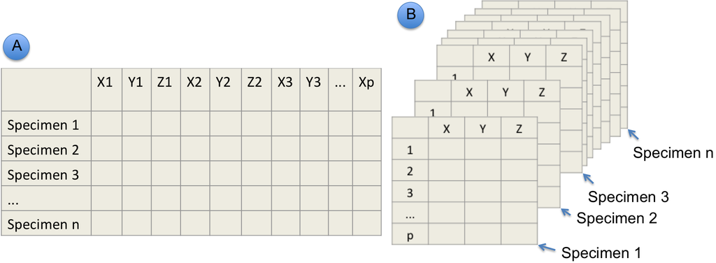

**Figure 1** 2D array and 3D array of landmark coordinate data. NOTE: This example shows 3D landmark coordinate data, but the same format would be used for 2D coordinate data.

## Converting a 2D array into a 3D array (`arrayspecs`)

### Function:

`arrayspecs(A, p, k)`

### Arguments:

- *A* A 2D array (matrix) containing landmark coordinates for a set of specimens
- *p* Number of landmarks
- *k* Number of dimensions (2 or 3)

This function converts a matrix of landmark coordinates into a 3D array (p x k x n), which is the required input format for many functions in *geomorph*. The input matrix can be arranged such that the coordinates of each landmark are found on a separate row, or that each row contains all landmark coordinates for a single specimen.

```r
A <- arrayspecs(mydata, p, k)  ## where mydata is a 2D array
A[,,1] ## look at just the first specimen
, , 1
          [,1]     [,2]
 [1,]  8.89372 53.77644
 [2,]  9.26840 52.77072
 [3,]  5.56104 54.21028
 [4,]  1.87340 52.75100
 [5,]  1.28180 53.18484
 [6,]  1.24236 53.32288
 [7,]  0.84796 54.70328
 [8,]  3.35240 55.76816
 [9,]  6.29068 55.70900
[10,]  8.87400 55.25544
[11,] 10.74740 55.43292
[12,] 14.39560 52.75100
```

## Converting a 3D array into a 2D array (`two.d.array`)

### Function:

`two.d.array(A)`

### Arguments:

`A` A 3D array containing landmark coordinates for a set of specimens

This function converts a 3D array (p x k x n) of landmark coordinates into a 2D array (n x [p x k]). The latter format of the shape data is useful for performing subsequent statistical analyses in R (e.g., PCA, MANOVA, PLS, etc.). Row labels are preserved if included in the original array.

```r
a <- two.d.array(mydata)  ## where mydata is a 3D array
a
          [,1]     [,2]      [,3]     [,4]     [,5]     [,6]     [,7]     [,8]     [,9]    [,10]
 [1,]  8.893720 53.77644  9.268400 52.77072 5.561040 54.21028 1.873400 52.75100 1.281800 53.18484
 [2,]  8.679762 54.57819  8.935628 53.83027 5.451914 54.65691 1.987882 52.68871 1.515514 53.02331
 [3,]  9.805328 56.06903 10.137712 55.27961 6.647680 55.73664 3.448484 53.86698 3.012230 54.34478
 [4,]  9.637164 58.03294  9.952104 56.77318 6.109836 57.94896 2.645496 55.89135 2.015616 56.62621
 [5,] 11.035692 58.75009 11.335110 57.85184 8.255382 58.92119 4.555431 57.46687 3.956595 58.08709
...
```

## Making a factor: group variables

Many analyses will require a grouping variable (a classifier) for the data. For small datasets, this can be made easily within R:

```r
group <- factor(c(0,0,1,0,0,1,1,0,0))  ## specimens assigned in order to group 0 or 1
names(group) <- dimnames(mydata)[[3]] ## assign specimen names from 3D array of data to the group classifier
group
[1] 0 0 1 0 0 1 1 0 0
Levels: 0 1
```

If the data have many specimens or many different groups, it may be easier to make a table in excel, save as a .csv file and import using `read.csv`. classifier.csv

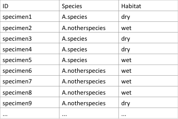

```r
classifier <- read.csv("classifier.csv", header=T, row.names=1)
is.factor(classifier$Habitat) ## check that it is a factor
[1] TRUE
classifier$Habitat
[1] dry wet dry dry wet wet wet wet dry ...
Levels: dry wet
```

Note: When reading in a data file, R usually treats character variables as factors, but numeric variables are not, and therefore must be coerced into factors. See `?factor` for more information. ## Lists Another common data structure in R is a list. In essence, a list is a generic vector containing other objects. In *geomorph*, the example data are all lists. e.g. plethodon:

```r
library(geomorph)
data(plethodon)
attributes(plethodon)
```

```
$names
[1] "land"    "links"   "species" "site"    "outline"
```

Here, plethodon is made up of 5 named objects (which are each vectors, matrices/2D arrays or 3D arrays). To access named objects within a list, use $, such as plethodon$links. The returned output of many *geomorph* functions is also in named list form. Parts of a list can also be accessed using numbers with double square brackets [[]]. So in the above example. links is the 2nd object in the plethodon list, and so can also be accessed by plethodon[[2]]. For more details on this, a good resource is the website R tutorial (http://www.r-tutor.com/r-introduction/list).

## Estimating missing landmarks (`estimate.missing`)

All analysis and plotting functions in *geomorph* require a full complement of landmark coordinates. Either the missing values are estimated, or subsequent analyses are performed on a subset dataset excluding specimens with missing values. Below is the function to estimate missing data, followed by steps of how to just exclude specimens with missing values.

### Function:

`estimate.missing(A, method = c("TPS", "Reg"))`

### Arguments:

- *A* A 3D array (p x k x n) containing landmark coordinates for a set of specimens
- *method* Method for estimating missing landmark locations

The function estimates the locations of missing landmarks for incomplete specimens in a set of landmark configurations, where missing landmarks in the incomplete specimens are designated by NA in place of the x,y,z coordinates. Two distinct approaches are implemented.

1. The first approach (`method="TPS"`) uses the thin-plate spline to interpolate landmarks on a reference specimen to estimate the locations of missing landmarks on a target specimen. Here, a reference specimen is obtained from the set of specimens for which all landmarks are present, Next, each incomplete specimen is aligned to the reference using the set of landmarks common to both. Finally, the thin-plate spline is used to estimate the locations of the missing landmarks in the target specimen (Gunz et al. 2009).
2. The second approach (method=“Reg”) is multivariate regression. Here each landmark with missing values is regressed on all other landmarks for the set of complete specimens, and the missing landmark values are then predicted by this linear regression model. Because the number of variables can exceed the number of specimens, the regression is implemented on scores along the first set of PLS axes for the complete and incomplete blocks of landmarks (see Gunz et al. 2009).

One can also exploit bilateral symmetry to estimate the locations of missing landmarks. Several possibilities exist for implementing this approach (see Gunz et al. 2009). Example R code for one implementation is found in Claude (2008).

Missing landmarks in a target specimen are designated by NA in place of the x,y,z coordinates. To make this so:

```r
any(is.na(mydata) ## check if there are NAs in the data
FALSE ## if false then,
mydata[which(mydata == -999)] <- NA ## change missing values from “-999” to NAs
```

.nts files give a value in the header that is used to designate missing data (often 9999, -999 etc.). The `which(mydata == -999)` searches for these values and replaces with NA.

To use the function, let’s use an example using Plethodon dataset:

```r
data(plethodon)
  plethland<-plethodon$land
  plethland[2,,2]<-plethland[6,,2]<-NA  ## create missing landmarks
  plethland[2,,5]<-plethland[6,,5]<-NA  ## create missing landmarks
  plethland[2,,10]<-NA  ## create missing landmarks
new.plethland <- estimate.missing(plethland,method="TPS")
new.plethland <- estimate.missing(plethland,method="Reg")
```

The function returns a 3D array with the missing landmarks estimated.

Instead of estimating missing, an alternative is to proceed with the specimens for which data are missing excluded. For example to make a dataset of only the complete specimens (starting with the dataset as 2D array), two ways are possible:

```
mydata
         [,1]     [,2]      [,3]     [,4]
 [1,]  8.893720 53.77644  9.268400 52.77072
 [2,]  8.679762 54.57819  8.935628 53.83027
 [3,]  9.805328 56.06903 NA NA
 [4,]  9.637164 58.03294  9.952104 56.77318
 [5,] NA NA 11.335110 57.85184
 [6,]  7.946625 55.71114  8.476400 54.82112
 [7,]  8.849841 58.66961  9.396387 57.82877
 [8,]  9.331504 56.36904 10.154872 55.31344
```

```r
newdata <- mydata[complete.cases(mydata),] ## keep only specimens with complete data
## OR
newdata <- na.omit(mydata) ## use only specimens without NAs
```

```
newdata
         [,1]     [,2]      [,3]     [,4]
 [1,]  8.893720 53.77644  9.268400 52.77072
 [2,]  8.679762 54.57819  8.935628 53.83027
 [3,]  9.637164 58.03294  9.952104 56.77318
 [4,]  7.946625 55.71114  8.476400 54.82112
 [5,]  8.849841 58.66961  9.396387 57.82877
 [6,]  9.331504 56.36904 10.154872 55.31344
```

These functions can be used to make a dataset of only the landmarks in all specimens, by inputting the matrix `mydata` in transpose, e.g., `t(mydata)`. Note that these methods will re-label the specimen or landmark numbers.

## Rotate a subset of 2D landmarks to common articulation angle (fixed.angle)

A function for rotating a subset of landmarks so that the articulation angle between subsets is constant. Presently, the function is only implemented for two-dimensional landmark data. ### Function:  
`fixed.angle(A, art.pt = NULL, angle.pts = NULL, rot.pts = NULL, angle = 0, degrees = FALSE)`

### Arguments:

- *A* A 3D array (p x k x n) containing landmark coordinates for a set of specimens
- *art.pt* A number specifying which landmark is the articulation point between the two landmark subsets
- *angle.pts* A vector containing numbers specifying which two points used to define the angle (one per subset)
- *rot.pts* A vector containing numbers specifying which landmarks are in the subset to be rotated
- *angle* An optional value specifying the additional amount by which the rotation should be augmented (in radians)
- *degrees* A logical value specifying whether the additional rotation angle is expressed in degrees or radians (radians is default)

This function standardizes the angle between two subsets of landmarks for a set of specimens. The approach assumes a simple hinge-point articulation between the two subsets, and rotates all specimens such that the angle between landmark subsets is equal across specimens (see Adams 1999). As a default, the mean angle is used, though the user may specify an additional amount by which this may be augmented.  
Example using Plethodon. Articulation point is landmark 1, rotate mandibular landmarks (2-5) relative to cranium

```r
data(plethspecies)
new.plethdata <- fixed.angle(plethspecies$land,
                             art.pt=1,
                             angle.pts=c(5,6),
                             rot.pts=c(2,3,4,5))
```

Function returns a 3D array containing the newly rotated data.

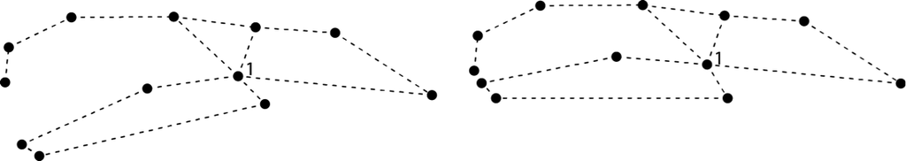

The position of the mandible before running fixed.angle (left) and after (right).